# Rotation and Vibration

Author

Daniel Fischer

# Introduction

Having established how electronic states define the potential energy landscape of a molecule, we now turn to the **motion of the nuclei** within this landscape. While electrons adjust almost instantaneously to nuclear positions, the heavier nuclei move much more slowly — a separation of timescales that forms the basis of the **Born–Oppenheimer approximation**.

This approximation allows us to treat the electrons and nuclei **adiabatically**: the electrons define an effective potential energy surface on which the nuclei move. Within this framework, molecular spectroscopy becomes a study of **nuclear motion** — rotations and vibrations — superimposed on the electronic structure.

For diatomic molecules, these nuclear motions are especially transparent: the system reduces to a single **internuclear coordinate** $R$, and the resulting dynamics explain the **fine structure** observed in molecular spectra. Rotational and vibrational energy levels reveal the geometry and stiffness of chemical bonds, providing a direct link between **quantum mechanics and measurable molecular properties**.

### Goals of this Chapter

By the end of this chapter, you should be able to:

1. Explain the **Born–Oppenheimer approximation** and its physical justification.
2. Derive the **electronic** and **nuclear Schrödinger equations** by separating electronic and nuclear motion.
3. Understand how **potential energy curves** act as effective potentials for nuclear dynamics.
4. Describe the **rotational** and **vibrational** motions of diatomic molecules using quantum-mechanical models.
5. Interpret how these motions give rise to **rotational–vibrational spectra** and characteristic energy scales.
6. Recognize the role of **nuclear spin statistics** in determining the population of molecular levels.

The concepts introduced here — quantized nuclear motion and potential energy surfaces — form the basis for understanding **rotational–vibrational spectra** and their experimental interpretation.

# 1. The Born-Oppenheimer Approximation

Understanding molecular vibrations and rotations requires us to solve the Schrödinger equation for a many-body system containing both electrons and nuclei. The complete quantum mechanical treatment of this problem is extremely complex, as all particles are coupled through Coulombic interactions. However, the large mass difference between electrons and nuclei ($M_{\text{nucleus}}/m_e \sim 10^3$–$10^5$) suggests a natural separation: electrons move much faster than nuclei and can adjust almost instantaneously to changes in nuclear positions. This physical insight forms the basis of the **Born-Oppenheimer approximation**, which allows us to treat electronic and nuclear motion separately. We first solve for the electronic structure at fixed nuclear geometries, and then use the resulting electronic energy as an effective potential governing nuclear motion.

## 1.1 The Complete Hamiltonian

The complete molecular Hamiltonian describes both electronic and nuclear degrees of freedom. We can write it as:

$$\hat{H} = \hat{H}_0 + \hat{T}_N$$

where $\hat{H}_0$ is the electronic Hamiltonian (including nuclear-nuclear repulsion) and $\hat{T}_N$ is the kinetic energy operator for the nuclei.

The electronic Hamiltonian is given by:

$$\hat{H}_0 = \hat{T}_e + \hat{V}_{eN} + \hat{V}_{ee} + V_{NN}$$

where $\hat{T}_e$ is the electronic kinetic energy, $\hat{V}_{eN}$ is the electron-nuclear attraction, $\hat{V}_{ee}$ is the electron-electron repulsion, and $V_{NN}$ is the nuclear-nuclear repulsion (which depends only on nuclear coordinates).

The nuclear kinetic energy operator is explicitly:

$$\hat{T}_N = -\sum_{k=1}^{N_{\text{nuc}}} \frac{\hbar^2}{2M_k} \nabla_k^2$$

where the sum runs over all nuclei, $M_k$ is the mass of nucleus $k$.

Since nuclear masses are much larger than the electron mass ($M_k \gg m_e$, typically by a factor of $10^3$ to $10^5$), the $\hat{T}_N$ term represents a small perturbation to the electronic problem. This mass difference is the physical basis for treating nuclear and electronic motion separately.

## 1.2 The Born-Oppenheimer Ansatz

We have already employed a separation of variables approach when solving for electronic wavefunctions—we separated the electronic coordinates from the nuclear coordinates by treating the nuclei as fixed. The Born-Oppenheimer approximation formalizes this idea by writing the total wavefunction as a product:

$$\Psi(\vec{r}_i, \vec{R}_k) = \chi(\vec{R}_k) \cdot \Phi(\vec{r}_i, \vec{R}_k)$$

where:  
- $\vec{r}_i$ denotes the coordinates of all electrons ($i = 1, \ldots, N_e$)  
- $\vec{R}_k$ denotes the coordinates of all nuclei ($k = 1, \ldots, N_{\text{nuc}}$)  
- $\chi(\vec{R}_k)$ describes the nuclear motion (the vibrational-rotational wavefunction)  
- $\Phi(\vec{r}_i, \vec{R}_k)$ is the electronic wavefunction

The electronic wavefunction $\Phi(\vec{r}_i, \vec{R}_k)$ is said to be **parametrically dependent** on the nuclear coordinates $\vec{R}_k$. This means that for each fixed configuration of the nuclei, we solve the electronic Schrödinger equation to obtain $\Phi$ as a function of the electronic coordinates $\vec{r}_i$. The nuclear positions appear as parameters in this electronic problem, not as dynamical variables. As the nuclei move, the electronic wavefunction adjusts to the new nuclear configuration, but we treat each nuclear geometry separately.

**Key assumption:** Electrons move much faster than nuclei (due to their much smaller mass), and they adjust essentially instantaneously to changes in the nuclear configuration. This implies that electronic and nuclear motions can be treated as independent to a good approximation, and their coupling can be neglected. In other words, vibrations and rotations do not induce transitions between different electronic states (non-adiabatic effects are neglected).

## 1.3 The Effective Nuclear Schrödinger Equation

To derive the equations governing electronic and nuclear motion, we substitute the Born-Oppenheimer ansatz into the time-independent Schrödinger equation:

$$\hat{H}\Psi = E\Psi$$

$$(\hat{H}_0 + \hat{T}_N)[\chi(\vec{R}_k) \Phi(\vec{r}_i, \vec{R}_k)] = E\,\chi(\vec{R}_k) \Phi(\vec{r}_i, \vec{R}_k)$$

Let us examine how $\hat{T}_N$ acts on the product $\chi(\vec{R}_k) \Phi(\vec{r}_i, \vec{R}_k)$. For a single nucleus $k$:

$$-\frac{\hbar^2}{2M_k}\nabla_k^2[\chi \Phi] = -\frac{\hbar^2}{2M_k}[\underbrace{(\nabla_k^2\chi)\Phi}_{\text{Term I}} + \underbrace{2(\nabla_k\chi)\cdot(\nabla_k\Phi)}_{\text{Term II}} + \underbrace{\chi(\nabla_k^2\Phi)}_{\text{Term III}}]$$

The Born-Oppenheimer approximation consists of neglecting the last two terms, which represent the coupling between nuclear and electronic motion. These terms are small because $\Phi$ varies slowly with nuclear coordinates (the electrons adjust adiabatically). Thus:

$$\hat{T}_N[\chi \Phi] \approx [\hat{T}_N\chi]\Phi$$

**NoteWhy Terms II and III are Neglected**

The justification for setting **Term II** (coupling) and **Term III** (diagonal correction) to zero relies on the **vast difference in mass** between the nuclei ($M_k$) and the electrons ($m_e$).

- **Small Magnitude:** Both neglected terms scale with the **inverse of the large nuclear mass, $\mathbf{1/M_k}$**. While Term I also scales with $1/M_k$ (it’s the nuclear kinetic energy), Terms II and III are small coupling effects. Because $M_k$ is thousands of times greater than $m_e$, the contributions of Terms II and III are negligible compared to the large electronic energy terms (scaled by $1/m_e$) that are retained in the overall Hamiltonian.
- **Decoupling:** Neglecting these small terms is the foundational step that allows the $\text{MO}$ problem to be **separated** into independent electronic and nuclear Schrödinger equations, dramatically simplifying the solution.

Substituting this approximation, we obtain:

$$\hat{H}_0\Phi \cdot \chi + \Phi \cdot \hat{T}_N\chi = E\,\chi\Phi$$

Dividing by $\chi\Phi$:

$$\frac{1}{\Phi}\hat{H}_0\Phi + \frac{1}{\chi}\hat{T}_N\chi = E$$

Since the first term depends only on electronic coordinates (with $\vec{R}_k$ as parameters) and the second only on nuclear coordinates, each must equal a constant for the equation to hold for all values of the coordinates. This yields two separate equations.

#### Electronic Schrödinger equation:

$$\hat{H}_0 \Phi_n^{el}(\vec{r}_i; \vec{R}_k) = E_n^{el}(\vec{R}_k) \Phi_n^{el}(\vec{r}_i; \vec{R}_k)$$

For each fixed nuclear geometry $\vec{R}_k$, we solve this equation to obtain the electronic energy $E_n^{el}(\vec{R}_k)$ and wavefunction $\Phi_n^{el}$. The electronic energy depends on the nuclear coordinates and defines the **potential energy surface** for nuclear motion. (We use semicolon notation to emphasize that $\vec{R}_k$ are parameters, not dynamical variables.)

#### Nuclear Schrödinger equation:

$$\left[\hat{T}_N + E_n^{el}(\vec{R}_k)\right] \chi_{n}(\vec{R}_k) = E_{n} \chi_{n}(\vec{R}_k)$$

The electronic energy curve $E_n^{el}(\vec{R}_k)$ from the electronic problem now acts as the effective potential energy for nuclear motion. The eigenvalues $E_n$ of this equation give the total energies of vibrational and rotational states within electronic state $n$.

## 1.4 Separation of Vibrational and Rotational Motion: The Diatomic Case

For a diatomic molecule, we can further separate the nuclear motion into vibrational and rotational components. Let us denote the internuclear distance as $R = |\vec{R}_2 - \vec{R}_1|$ and introduce center-of-mass and relative coordinates.

The nuclear kinetic energy operator for a diatomic molecule can be written in terms of the reduced mass $\mu = \frac{M_1 M_2}{M_1 + M_2}$:

$$\hat{T}_N = -\frac{\hbar^2}{2\mu}\nabla^2$$

where the Laplacian is with respect to the relative coordinate $\vec{R} = \vec{R}_2 - \vec{R}_1$.

#### Transformation to spherical coordinates:

In spherical coordinates $(R, \theta, \phi)$, the Laplacian takes the form:

$$\nabla^2 = \frac{1}{R^2}\frac{\partial}{\partial R}\left(R^2 \frac{\partial}{\partial R}\right) + \frac{1}{R^2\sin\theta}\frac{\partial}{\partial\theta}\left(\sin\theta\frac{\partial}{\partial\theta}\right) + \frac{1}{R^2\sin^2\theta}\frac{\partial^2}{\partial\phi^2}$$

We recognize that the angular part is related to the squared angular momentum operator:

$$\hat{L}^2 = -\hbar^2\left[\frac{1}{\sin\theta}\frac{\partial}{\partial\theta}\left(\sin\theta\frac{\partial}{\partial\theta}\right) + \frac{1}{\sin^2\theta}\frac{\partial^2}{\partial\phi^2}\right]$$

Therefore, the kinetic energy operator becomes:

$$\hat{T}_N = -\frac{\hbar^2}{2\mu R^2}\frac{\partial}{\partial R}\left(R^2 \frac{\partial}{\partial R}\right) + \frac{\hat{L}^2}{2\mu R^2}
\tag{1}$$

The first term is the **radial kinetic energy** (vibrational), and the second term is the **rotational kinetic energy**.

#### Separation of variables:

We write the nuclear wavefunction as:

$$\chi(R, \theta, \phi) = \frac{u(R)}{R} Y_{J,M}(\theta, \phi)$$

where $Y_{J,M}(\theta, \phi)$ are spherical harmonics (eigenfunctions of $\hat{L}^2$ with eigenvalue $J(J+1)\hbar^2$), and the factor $1/R$ simplifies the radial equation.

Substituting into the nuclear Schrödinger equation:

$$\left[-\frac{\hbar^2}{2\mu R^2}\frac{\partial}{\partial R}\left(R^2 \frac{\partial}{\partial R}\right) + \frac{\hat{L}^2}{2\mu R^2} + E_n^{el}(R)\right]\frac{u(R)}{R} Y_{J,M} = E\,\frac{u(R)}{R} Y_{J,M}$$

Using $\hat{L}^2 Y_{J,M} = J(J+1)\hbar^2 Y_{J,M}$ and simplifying the radial derivative:

$$-\frac{\hbar^2}{2\mu R^2}\frac{d}{dR}\left(R^2 \frac{d}{dR}\frac{u}{R}\right) = -\frac{\hbar^2}{2\mu}\frac{d^2u}{dR^2}$$

we obtain the **radial Schrödinger equation**:

$$\left[-\frac{\hbar^2}{2\mu}\frac{d^2}{dR^2} + \frac{J(J+1)\hbar^2}{2\mu R^2} + E_n^{el}(R)\right]u(R) = E_{nJ}\,u(R)$$

This equation describes vibration in an effective potential:

$$V_{\text{eff}}(R) = E_n^{el}(R) + \frac{J(J+1)\hbar^2}{2\mu R^2}$$

The second term is the **centrifugal potential**, which depends on the rotational quantum number $J$.

# 2. Molecular Rotation: The Rigid Rotor

The final step in the Born-Oppenheimer approximation for diatomic molecules, as shown in the previous section, is the separation of the nuclear motion into vibrational (radial) and rotational (angular) components. We now proceed to simplify and solve the angular part of the nuclear Schrödinger equation by employing the **rigid rotor approximation**.

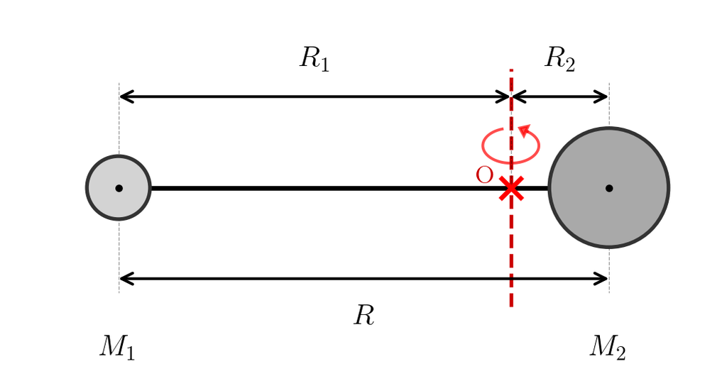

```python
import matplotlib.pyplot as plt
import matplotlib.patches as patches
import numpy as np

# --- Functional Fits (Based on Known Theoretical Results) ---
# --- Set up plot styling ---
plt.rcParams['text.usetex'] = True
plt.rcParams['font.family'] = 'serif'
plt.rcParams['font.size'] = 12


fig, ax = plt.subplots(1, 1, figsize=(6, 3))

# Positions
M1_pos = 2.5
M2_pos = 9.5
COM_pos = (M1_pos * 1 + M2_pos * 4) / 5


# Draw elliptical rotation arrow around the center of mass
theta = np.linspace(0.6 * np.pi, 2.3 * np.pi, 100)  # 1.7*pi to leave gap for arrowhead
ellipse_a = 0.4  # semi-major axis (horizontal)
ellipse_b = 0.25  # semi-minor axis (vertical)
x_ellipse = COM_pos + ellipse_a * np.cos(theta)
y_ellipse = 3.1 + ellipse_b * np.sin(theta)

ax.plot(x_ellipse, y_ellipse, 'r-', linewidth=1.5, alpha=0.7, zorder=1)

# Add arrowhead at the end of the ellipse
arrow_x = COM_pos + ellipse_a * np.cos(2.3 * np.pi)
arrow_y = 3.1 + ellipse_b * np.sin(2.3 * np.pi)
# Direction tangent to ellipse
dx = -ellipse_a * np.sin(2.3 * np.pi)
dy = ellipse_b * np.cos(2.3 * np.pi)
# Normalize
norm = np.sqrt(dx**2 + dy**2)
dx, dy = dx/norm * 0.02, dy/norm * 0.02

ax.arrow(arrow_x, arrow_y, dx, dy, head_width=0.15, head_length=0.1,
         fc='red', ec='red', linewidth=1.5, alpha=0.7, zorder=1)


# Draw rotation axis (dashed red line)
ax.axvline(COM_pos, ymin=0.16, ymax=0.84, color='#CC0000',
           linewidth=2, linestyle='--', zorder=1)

# Draw bond line
ax.plot([M1_pos, M2_pos], [2.5, 2.5], 'k-', linewidth=2.5, zorder=2)

# Draw atoms
# Smaller atom (M1)
circle1 = patches.Circle((M1_pos, 2.5), 0.45, color='lightgray',
                         ec='#333', linewidth=2, zorder=3)
ax.add_patch(circle1)
ax.plot(M1_pos, 2.5, 'ko', markersize=3, zorder=4)

# Larger atom (M2)
circle2 = patches.Circle((M2_pos, 2.5), 0.85, color='darkgray',
                         ec='#333', linewidth=2, zorder=3)
ax.add_patch(circle2)
ax.plot(M2_pos, 2.5, 'ko', markersize=3, zorder=4)

# Center of mass marker (red X)
ax.plot(COM_pos, 2.5, 'rx', markersize=12, markeredgewidth=2.5, zorder=5)

# Extension lines (dashed, thin)
for pos in [M1_pos, COM_pos, M2_pos]:
    ax.plot([pos, pos], [2.5, 4.0], 'k--', linewidth=0.5, alpha=0.4)
for pos in [M1_pos, M2_pos]:
    ax.plot([pos, pos], [2.5, 1.0], 'k--', linewidth=0.5, alpha=0.4)

# Arrows
arrow_props = dict(arrowstyle='<->', color='black', lw=1.5,
                   shrinkA=0, shrinkB=0, mutation_scale=15)

# R1 arrow
ax.annotate('', xy=(COM_pos, 3.8), xytext=(M1_pos, 3.8), arrowprops=arrow_props)
ax.text((M1_pos + COM_pos)/2, 4.15, r'$R_1$', fontsize=16,
        ha='center', va='bottom', style='italic')

# R2 arrow
ax.annotate('', xy=(M2_pos, 3.8), xytext=(COM_pos, 3.8), arrowprops=arrow_props)
ax.text((COM_pos + M2_pos)/2, 4.15, r'$R_2$', fontsize=16,
        ha='center', va='bottom', style='italic')

# R arrow
ax.annotate('', xy=(M2_pos, 1.2), xytext=(M1_pos, 1.2), arrowprops=arrow_props)
ax.text((M1_pos + M2_pos)/2, 0.85, r'$R$', fontsize=16,
        ha='center', va='top', style='italic')

# Labels
ax.text(M1_pos, 0.4, r'$M_1$', fontsize=16, ha='center', va='top', style='italic')
ax.text(M2_pos, 0.4, r'$M_2$', fontsize=16, ha='center', va='top', style='italic')
ax.text(COM_pos - 0.35, 2.5, 'O', fontsize=14, ha='center', va='bottom',
        color='#CC0000', weight='bold')

# Axis settings
ax.set_xlim(1, 11)
ax.set_ylim(0, 5)
ax.set_aspect('equal')
ax.axis('off')

plt.tight_layout()
plt.show()
```

## 2.1 Rotational Energy Levels

From the previous section, we saw that the nuclear Hamiltonian for a diatomic molecule (see Equation 1) contains the term:

$$\hat{H}_{\text{rot}} = \frac{\hat{L}^2}{2\mu R^2}$$

which represents the rotational kinetic energy. In the **rigid rotor approximation**, we assume that the molecule does not vibrate, i.e., the internuclear distance $R$ is fixed at its equilibrium value $R_e$. This decouples rotation from vibration and allows us to treat the rotational problem independently.

With $I = \mu R_e^2$ (the moment of inertia), we can write:

$$\hat{H}_{\text{rot}} = \frac{\hat{L}^2}{2I},$$

which has the same form as the classical expression $E_{\text{rot}} = J^2/2I$.

The eigenfunctions of $\hat{L}^2$ are the spherical harmonics $Y_{J,M}(\theta, \phi)$, with eigenvalues:

$$\hat{L}^2 Y_{J,M} = J(J+1)\hbar^2 Y_{J,M}$$

where $J = 0, 1, 2, 3, \ldots$ is the **rotational quantum number**, and $M = -J, -J+1, \ldots, J-1, J$ is the projection of angular momentum along the space-fixed $z$-axis.

The rotational energy levels are therefore:

$$E_{\text{rot}}(J) = \frac{J(J+1)\hbar^2}{2I} = B J(J+1)$$

where we have introduced the **rotational constant**:

$$B = \frac{\hbar^2}{2I} = \frac{\hbar^2}{2\mu R_e^2}$$

Each energy level with quantum number $J$ is $(2J+1)$-fold degenerate due to the different possible values of $M$.

**Energy spacing:** The spacing between adjacent rotational levels increases linearly with $J$:

$$\Delta E = E(J+1) - E(J) = 2B(J+1)$$

Typical values of the rotational constant $B$ are in the range of $10^{-4}$ to $10^{-2}$ eV, corresponding to rotational transition energies in the **microwave and far-infrared region** (wavelengths $\sim 10^{-5}$ to $10^{-1}$ m). This is much smaller than vibrational energies ($\sim 0.1$–$0.5$ eV) and electronic energies ($\sim 1$–$10$ eV).

## 2.2 Nuclear Spin Statistics in Homonuclear Molecules

For homonuclear diatomic molecules, an constraint arises from the symmetry properties of identical nuclei. Consider the example of H$_2$, where both nuclei are protons.

Protons are fermions with spin $I = 1/2$. The Pauli exclusion principle requires that the total wavefunction (including nuclear spin) must be **antisymmetric** under exchange of the two identical nuclei.

#### Spin exchange symmetry:

The nuclear spin wavefunctions can be combined into symmetric and antisymmetric combinations:  
- **Symmetric (triplet, $I_{\text{tot}} = 1$)**: Three states with parallel spins, e.g., $|\uparrow\uparrow\rangle$, $|\downarrow\downarrow\rangle$, and $\frac{1}{\sqrt{2}}(|\uparrow\downarrow\rangle + |\downarrow\uparrow\rangle)$. These are called **ortho-H$_2$**.  
- **Antisymmetric (singlet, $I_{\text{tot}} = 0$)**: One state $\frac{1}{\sqrt{2}}(|\uparrow\downarrow\rangle - |\downarrow\uparrow\rangle)$. This is called **para-H$_2$**.

#### Spatial exchange symmetry:

For a homonuclear diatomic molecule, exchanging the two nuclei is equivalent to a rotation of 180° about an axis perpendicular to the molecular axis (or equivalently, to a spatial inversion through the center of mass). For rotational wavefunctions (spherical harmonics $Y_{J,M}$), the parity is $(-1)^J$. Therefore:  
- **Even $J$**: rotational wavefunction is symmetric under exchange  
- **odd $J$**: rotational wavefunction is antisymmetric under exchange

#### Total exchange symmetry:

To satisfy the Pauli principle (total wavefunction antisymmetric):  
- **Ortho-H$_2$** (symmetric nuclear spin): requires **odd $J$** (antisymmetric spatial wavefunction)  
- **Para-H$_2$** (antisymmetric nuclear spin): requires **even $J$** (symmetric spatial wavefunction)

These are distinct molecular species that do not interconvert easily (the conversion requires a nuclear spin flip, which is very slow). At room temperature, the equilibrium mixture is 3:1 ortho:para, reflecting the statistical weights (3 triplet states vs. 1 singlet state). At low temperatures, para-H$_2$ dominates because the lowest rotational state is $J = 0$.

#### Example: D$_2$ (deuterium molecule)

Deuterium nuclei are bosons with spin $I = 1$. Bosons require a **symmetric** total wavefunction. Following similar logic:  
- **Symmetric nuclear spin states** ($I_{\text{tot}} = 0, 2$, 6 states total): require **even $J$** (symmetric spatial wavefunction)  
- **Antisymmetric nuclear spin state** ($I_{\text{tot}} = 1$, 3 states): require **odd $J$** (antisymmetric spatial wavefunction)

The equilibrium ratio at high temperature is 6:3 or 2:1 (ortho:para).

## 2.3 Rotational Degrees of Freedom in Diatomic Molecules

A diatomic molecule has only **two rotational degrees of freedom**, corresponding to rotations about axes perpendicular to the internuclear axis. To understand this, consider the molecular axis as the $z$-axis:

- **Rotations about the $x$ and $y$ axes**: These change the orientation of the molecule in space and correspond to genuine rotational motion with significant moment of inertia $I = \mu R_e^2$.
- **Rotation about the $z$-axis (molecular axis)**: For a diatomic molecule consisting of spherically symmetric atoms, rotation about the internuclear axis does not change the nuclear configuration. The moment of inertia about this axis is negligible (essentially zero for point-like nuclei). Therefore, this degree of freedom does not contribute to the classical or quantum rotational energy.

When electronic angular momentum is present (in electronically excited states), the rotational situation becomes more complex. Electronic motion can be thought of as occurring **“around” the molecular axis** (the $z$-axis in the molecular frame), characterized by the quantum number **$\Lambda$** (the projection of the electronic orbital angular momentum onto the molecular axis). This electronic rotation is **carried along** when the molecule rotates, contributing energy to the total angular motion. The total angular momentum, $\vec{J}$, is the vector sum of the nuclear rotational angular momentum ($\vec{N}$, from the rotation of the nuclear framework) and the electronic angular momentum.

- **For $\Sigma$ states ($\Lambda = 0$):** There is no electronic rotation about the axis. The total angular momentum $\vec{J}$ is simply equal to the nuclear rotational angular momentum $\vec{N}$ ($\mathbf{J=N}$), and the simple $E_J = B J(J+1)$ treatment applies directly.
- **For states with $\Lambda > 0$ (e.g., $\Pi$ states):** The persistent electronic angular momentum $\Lambda$ is coupled to $\vec{N}$. This coupling **lifts the rotational ground state** and forces the rotational quantum number $J$ to start from $J = \Lambda, \Lambda+1, \Lambda+2, \dots$ (instead of $J=0$), effectively adding the electronic energy contribution into the molecular rotation.

This vector coupling of electronic and nuclear angular momenta is described by **Hund’s coupling cases** (a-e).

**Note💡 Thermodynamics: Rotational Energy and Equipartition**

The rotational motion of molecules is directly relevant to their **heat capacity** and **internal thermal energy**.

According to the **Equipartition Theorem**, at high enough temperatures ($T \gg \Theta_{\text{rot}}$, where $\Theta_{\text{rot}} = B/k_B$ is the characteristic rotational temperature), every translational and rotational degree of freedom contributes $\mathbf{\frac{1}{2} k_B T}$ to the average thermal energy of a molecule.

- **Linear Molecules (Diatomics):** Have **two** rotational degrees of freedom. They contribute $\mathbf{k_B T}$ to the total thermal energy.
- **Non-linear Molecules:** Have **three** rotational degrees of freedom. They contribute $\mathbf{\frac{3}{2} k_B T}$ to the total thermal energy.

This theorem provides a powerful link between quantum mechanical degrees of freedom and macroscopic thermodynamic properties.

## 2.4 Centrifugal Distortion

The rigid rotor approximation breaks down at high rotational quantum numbers. As $J$ increases, the centrifugal force stretches the bond, increasing the moment of inertia $I$ and decreasing the rotational constant. This leads to a **centrifugal distortion correction**:

$$E_{\text{rot}}(J) = BJ(J+1) - D_J [J(J+1)]^2$$

where $D_J$ is the centrifugal distortion constant, typically much smaller than $B$ (by a factor of $\sim 10^{-3}$ to $10^{-6}$). This correction becomes significant only for high $J$ values and is important for precision spectroscopy.

# 3. Molecular Vibration

From Section 1.4, we derived the radial Schrödinger equation for nuclear motion in a diatomic molecule:
$$\left[-\frac{\hbar^2}{2\mu}\frac{d^2}{dR^2} + \frac{J(J+1)\hbar^2}{2\mu R^2} + E_n^{el}(R)\right]u(R) = E_{nJ}\,u(R)$$

This equation describes the vibrational motion in the effective potential:
$$V_{\text{eff}}(R) = E_n^{el}(R) + \frac{J(J+1)\hbar^2}{2\mu R^2}$$

The first term is the electronic potential energy surface, and the second is the centrifugal potential arising from rotation. There is no general analytical solution to this equation because it depends on the specific form of $E_n^{el}(R)$. However, analytical solutions exist for certain approximations to the potential energy curve. We will examine two key analytical models: the **Harmonic Oscillator** and the more realistic **Morse Potential**.

## 3.1 The Harmonic Approximation

Near the equilibrium distance $R_e$, we can expand the electronic potential energy in a Taylor series. Since $E_n^{el}(R)$ has a minimum at $R_e$, the first derivative vanishes and we obtain:

$$E_n^{el}(R) \approx E_n^{el}(R_e) + \frac{1}{2}k(R - R_e)^2 + \mathcal{O}[(R-R_e)^3]$$

where $k = \left.\frac{d^2 E_n^{el}}{dR^2}\right|_{R=R_e}$ is the **force constant**. This is the **harmonic oscillator approximation**.

For small vibrational amplitudes and low rotational quantum numbers, we can also neglect the centrifugal term. Setting $x = R - R_e$ and shifting the energy zero to $E_n^{el}(R_e)$, the radial equation becomes:

$$-\frac{\hbar^2}{2\mu}\frac{d^2u}{dx^2} + \frac{1}{2}kx^2 u = E_{\text{vib}}\,u$$

This is the standard quantum harmonic oscillator equation. As we have seen previously, the energy eigenvalues are:

$$E_{\text{vib}}(v) = \hbar\omega\left(v + \frac{1}{2}\right), \qquad v = 0, 1, 2, \ldots$$

where $v$ is the **vibrational quantum number** and:

$$\omega = \sqrt{\frac{k}{\mu}}$$

is the classical oscillation frequency.

**Key features:**

- The vibrational levels are **equally spaced** with spacing $\Delta E = \hbar\omega$
- The **zero-point energy** is $E_0 = \frac{1}{2}\hbar\omega$ (the molecule vibrates even in its lowest state)
- Typical vibrational energies are in the range $(0.01 - 0.5)$ eV, corresponding to **infrared wavelengths** ($\sim 1$–$100$ μm)
- The selection rule for vibrational transitions (in the harmonic approximation) is $\Delta v = \pm 1$

The harmonic approximation works well for low vibrational levels but fails at higher energies where anharmonic effects become important and eventually as the molecule approaches dissociation.

## 3.2 The Morse Potential

A more realistic description of molecular vibrations includes **anharmonicity**—the fact that the potential energy curve is not perfectly parabolic. As the bond stretches, it becomes easier to stretch further (the restoring force weakens), and eventually the molecule dissociates when $R \to \infty$.

The **Morse potential** provides an excellent analytical model that captures these features:

$$V_{\text{Morse}}(R) = E_B\left[1 - e^{-a(R-R_e)}\right]^2$$

where:  
- $E_B$ is the **binding energy** (depth of the potential well measured from the minimum)  
- $R_e$ is the equilibrium bond length  
- $a = \sqrt{\frac{k}{2E_B}}$ is a parameter that determines the “width” of the potential (related to the force constant $k$)

The radial Schrödinger equation with the Morse potential (neglecting the centrifugal term for simplicity) has **analytical solutions**. The energy eigenvalues are:

$$E_{\text{vib}}(v) = \hbar\omega\left(v + \frac{1}{2}\right) - \chi_e\hbar\omega\left(v + \frac{1}{2}\right)^2$$

where:

$$\omega = a\sqrt{\frac{2E_B}{\mu}}$$

is related to the harmonic frequency, and:

$$\chi_e = \frac{\hbar\omega}{4E_B}$$

is the **anharmonicity constant** (typically $\chi_e \approx 0.01$–$0.05$ for most diatomic molecules).

**Key features of the Morse oscillator:**

- The energy levels are **not equally spaced**—the spacing decreases as $v$ increases:

  $$\Delta E(v \to v+1) = \hbar\omega[1 - 2\chi_e(v+1)]$$
- There is a **finite number of bound vibrational states**. The maximum vibrational quantum number is approximately:

  $$v_{\max} \approx \frac{1}{2\chi_e} - 1 = \frac{2E_B}{\hbar\omega} - 1$$

  This limit occurs because the energy spacing $\Delta E$ approaches zero. For any level $v$ where the derived spacing $\Delta E(v \to v+1)$ would become **negative**, the state is unphysical and not bound, thus setting the maximum possible bound state at $v_{\max}$.
- For $v > v_{\max}$, the energy exceeds the dissociation limit and the molecule is no longer bound.
- The dissociation energy measured from the ground state is:

  $$D_0 = E_B - E_{\text{vib}}(v=0) = E_B - \frac{1}{2}\hbar\omega(1 - \chi_e/2)$$

The Morse potential provides an excellent description of real molecular potentials for most diatomic molecules, especially for vibrational levels up to dissociation. It is widely used in molecular spectroscopy to analyze vibrational structure.

The figure below visually contrasts the Morse potential and the Harmonic approximation potential energy curves for a diatomic molecule. The blue solid line represents the Morse potential, which is asymmetric and flattens out to a Dissociation Limit as the internuclear distance ($R$) increases. The blue horizontal lines show the Morse vibrational energy levels, demonstrating the effect of anharmonicity: the spacing between adjacent levels decreases as the vibrational quantum number $v$ increases. In contrast, the red dashed line (Harmonic approximation) is a perfect parabola, and its corresponding energy levels (red dashed horizontal lines) are equally spaced and incorrectly extend indefinitely beyond the true dissociation limit. The figure also clarifies the difference between the binding energy ($E_B$) at the potential minimum and the spectroscopic dissociation energy ($D_0$) measured from the zero-point energy ($v=0$).

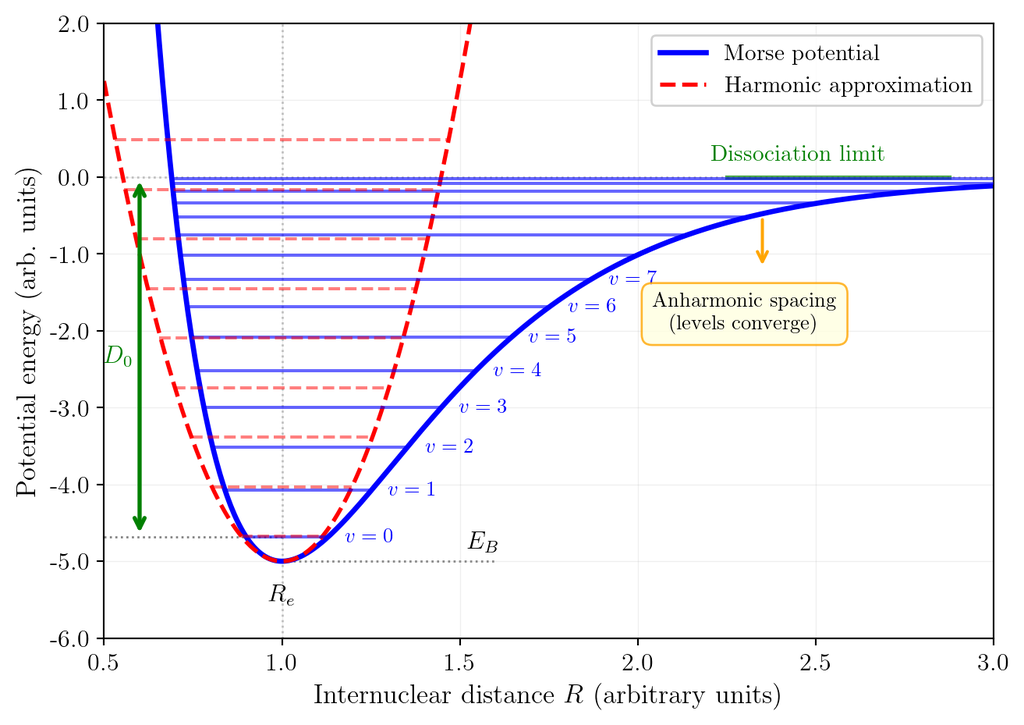

```python
import matplotlib.pyplot as plt
import numpy as np

# --- Set up plot styling ---
plt.rcParams['text.usetex'] = True
plt.rcParams['font.family'] = 'serif'
plt.rcParams['font.size'] = 12



def find_turning_points(R, V, E_v):
    """
    Find inner and outer classical turning points where V(R) = E_v
    Returns (R_min, R_max) or (None, None) if not found
    """
    diff = V - E_v
    # Find where sign changes (crossing points)
    sign_changes = np.where(np.diff(np.sign(diff)))[0]

    if len(sign_changes) >= 2:
        # Inner turning point (first crossing)
        R_min = R[sign_changes[0]]
        # Outer turning point (last crossing)
        R_max = R[sign_changes[-1]]
        return R_min, R_max
    else:
        R_min = R[sign_changes[0]]
        return R_min, 5

# Set up the figure
fig, ax = plt.subplots(1, 1, figsize=(7, 5))

# Parameters for the potentials
R_e = 1.0  # equilibrium distance (arbitrary units)
E_B = 5.0  # binding energy (eV)
k = 50.0   # force constant
mu = 120.0   # reduced mass (arbitrary units)
hbar = 1.0 # set to 1 for simplicity

# Calculate derived parameters
a = np.sqrt(k / (2 * E_B))
omega = np.sqrt(k / mu)
chi_e = (hbar * omega) / (4 * E_B)

# R values for plotting
R = np.linspace(0.5, 3.0, 500)

# Morse potential
V_morse = E_B * (1 - np.exp(-a * (R - R_e)))**2

# Harmonic potential
V_harmonic = 0.5 * k * (R - R_e)**2

# Plot potentials
ax.plot(R, V_morse, 'b-', linewidth=2.5, label='Morse potential', zorder=2)
ax.plot(R, V_harmonic, 'r--', linewidth=2, label='Harmonic approximation', zorder=2)

# Plot vibrational levels for Morse potential
n_levels_morse = int(1 / (2 * chi_e))  # maximum number of levels
v_values_morse = np.arange(0, n_levels_morse) # min(n_levels_morse, 15))  # limit to 15 for clarity

for v in v_values_morse:
    E_v = hbar * omega * (v + 0.5) - chi_e * hbar * omega * (v + 0.5)**2
    if E_v < E_B:  # only plot bound states
        R_min, R_max = find_turning_points(R, V_morse, E_v)
        if R_min is not None and R_max is not None:
            ax.hlines(E_v, R_min, R_max, colors='blue', linewidth=1.5,
                     alpha=0.6, zorder=3)
            # Add quantum number label for first few levels
            if v < 8:
                ax.text(R_max + 0.05, E_v, f'$v={v}$', fontsize=10,
                       va='center', color='blue')


# Plot vibrational levels for harmonic potential
n_levels_harmonic = 18  # show fewer levels since they extend beyond binding energy
for v in range(n_levels_harmonic):
    E_v = hbar * omega * (v + 0.5)
    if E_v < E_B+1.1:
        R_min, R_max = find_turning_points(R, V_harmonic, E_v)

        if R_min is not None and R_max is not None:
            ax.hlines(E_v, R_min, R_max, colors='red', linewidth=1.5,
                     alpha=0.5, linestyle='--', zorder=3)

# Mark equilibrium distance
ax.axvline(R_e, color='gray', linestyle=':', linewidth=1, alpha=0.5, zorder=1)
ax.text(R_e, -0.3, r'$R_e$', fontsize=12, ha='center', va='top')

# Mark binding energy
ax.axhline(E_B, color='gray', linestyle=':', linewidth=1, alpha=0.5, zorder=1)

# Mark dissociation limit
ax.axhline(E_B, xmin=0.7, xmax=0.95, color='green', linewidth=2,
          alpha=0.7, zorder=1)
ax.text(2.7, E_B + 0.15, 'Dissociation limit', fontsize=11,
       ha='right', va='bottom', color='green', style='italic')

# Mark ground state and D_0
E_0_morse = hbar * omega * 0.5 - chi_e * hbar * omega * 0.25
ax.annotate('', xy=(0.6, E_B), xytext=(0.6, E_0_morse),
            arrowprops=dict(arrowstyle='<->', color='green', lw=2))
ax.text(0.5, (E_B + E_0_morse)/2, r'$D_0$', fontsize=12,
       ha='left', va='center', color='green', fontweight='bold')
ax.hlines(E_0_morse,0,1, color='k', linestyle=':', linewidth=1, alpha=0.5, zorder=1)
ax.hlines(0,1,1.6, color='k', linestyle=':', linewidth=1, alpha=0.5, zorder=1)
ax.text(1.52, 0.1, r'$E_B$', fontsize=12, ha='left', va='bottom')



# Labels and formatting
ax.set_xlabel('Internuclear distance $R$ (arbitrary units)', fontsize=13)
ax.set_ylabel('Potential energy (arb. units)', fontsize=13)
#ax.set_title('Molecular Potential Energy Curves and Vibrational Levels',
#            fontsize=14, fontweight='bold', pad=15)
ax.legend(loc='upper right', fontsize=11, framealpha=0.9)
ax.set_xlim(0.5, 3.0)
ax.set_ylim(-0.5, 6.5)
ax.grid(True, alpha=0.2, linestyle='-', linewidth=0.5)

# Get current y-axis tick locations
yticks = ax.get_yticks()
ax.set_yticks(yticks)
# Set new labels (shifted)
ax.set_yticklabels([f'{y - 5:.1f}' for y in yticks])


# Add text annotation explaining anharmonicity
ax.text(2.3, 3.5, 'Anharmonic spacing\n(levels converge)',
       fontsize=10, ha='center', va='top',
       bbox=dict(boxstyle='round,pad=0.5', facecolor='lightyellow',
                 edgecolor='orange', alpha=0.8))

# Add arrow pointing to level convergence
ax.annotate('', xy=(2.35, 3.8), xytext=(2.35, 4.5),
            arrowprops=dict(arrowstyle='->', color='orange', lw=1.5))

plt.tight_layout()
#plt.savefig('molecular_potentials.png', dpi=300, bbox_inches='tight',
#           facecolor='white')
plt.show()
```

# 4. Coupling Between Rotation and Vibration

In our treatment so far, we have largely treated rotation and vibration as independent degrees of freedom. However, in reality, these motions are **coupled**, leading to a continuous exchange of energy between them in a vibrating molecule.

The total energy of the molecule (excluding electronic and translational components) can be written as the sum of the two distinct quantized motions:

$$E_{\text{nJ}} \approx E_{\text{vib}}(v) + E_{\text{rot}}(J)$$

The reason this approximation breaks down is that the **moment of inertia ($I$)** depends on the instantaneous internuclear distance $R(t)$, which varies during vibration. As the bond stretches (vibrates), the moment of inertia changes, thus directly affecting the rotational energy. Conversely, rotation imposes a centrifugal force that affects the effective vibrational potential. This interdependent relationship constitutes the **rovibrational coupling**.

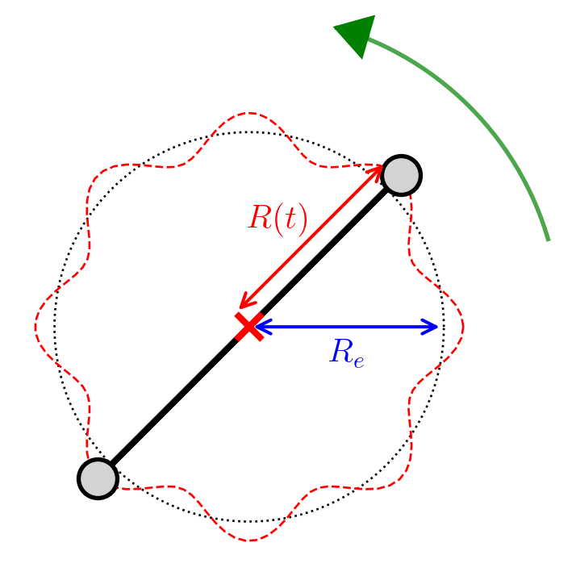

```python
import matplotlib.pyplot as plt
import numpy as np

# --- Set up plot styling ---
plt.rcParams['text.usetex'] = True
plt.rcParams['font.family'] = 'serif'
plt.rcParams['font.size'] = 16

fig, ax = plt.subplots(1, 1, figsize=(4, 4))

# Center position
center_x, center_y = 0, 0

# Draw the "trajectory" cloud (oscillating rotation path)
# This represents the trajectory of the molecule as it rotates and vibrates
n_snapshots = 120
angles = np.linspace(0, 2*np.pi, n_snapshots) # , endpoint=False)

# Parameters for oscillation
R_min = 0.45  # minimum bond length
R_max = 0.55 # maximum bond length
n_osc =  8

# draw circle
x_circle= 0.5 * np.cos(angles)
y_circle= 0.5 * np.sin(angles)
ax.plot(x_circle, y_circle, 'k:', lw = 1)

# draw oscillating circle
midpoint = (R_min + R_max) / 2
ampl = (R_max - R_min) / 2
x_osccircle=  (midpoint + ampl*np.cos(angles*n_osc))* np.cos(angles)
y_osccircle= (midpoint + ampl*np.cos(angles*n_osc)) * np.sin(angles)
ax.plot(x_osccircle, y_osccircle, 'r--', lw = 1)


# Draw the outer "cloud" boundary (dashed red line)
theta = np.linspace(0, 2*np.pi, 100)

# Draw the current molecule position (solid)
current_angle = np.pi / 4  # 45 degrees
current_R = midpoint + ampl*np.cos(current_angle*n_osc)

# Atom positions
x1_current = -1 * current_R * np.cos(current_angle)
y1_current = -1 * current_R * np.sin(current_angle)
x2_current = current_R * np.cos(current_angle)
y2_current = current_R * np.sin(current_angle)

# Draw bond
ax.plot([x1_current, x2_current], [y1_current, y2_current],
        'k-', linewidth=3, zorder=10)

# Draw atoms
ax.plot(x1_current, y1_current, 'o', color='lightgray',
        markersize=18, markeredgecolor='black', markeredgewidth=2, zorder=11)
ax.plot(x2_current, y2_current, 'o', color='lightgray',
        markersize=18, markeredgecolor='black', markeredgewidth=2, zorder=11)

# Draw center of mass
com_x = 0 # 0.25 * current_R * np.cos(current_angle)
com_y = 0 # 0.25 * current_R * np.sin(current_angle)
ax.plot(com_x, com_y, 'rx', markersize=12, markeredgewidth=3, zorder=12)


# Draw arrows showing R(t) (bond length)
mid_x = (x1_current + x2_current) / 2
mid_y = (y1_current + y2_current) / 2

# Arrow from center to bond midpoint
ax.annotate('', xy=(mid_x, mid_y), xytext=(com_x, com_y),
            arrowprops=dict(arrowstyle='<->', color='black', lw=1.5))

# Label R(t)
#label_x = (mid_x + com_x) / 2 + 0.1
#label_y = (mid_y + com_y) / 2 - 0.15
#ax.text(label_x, label_y, r'$R(t)$', fontsize=14, ha='center', va='top')


# Draw R(t) arrow
offset=0.05
off_x = -np.sin(current_angle)*offset
off_y = np.cos(current_angle)*offset
ax.annotate('', xy=(x2_current + off_x, y2_current + off_y), xytext=(com_x + off_x, com_y + off_y), color='red',
            arrowprops=dict(arrowstyle='<->', color='red', lw=1.5), zorder=15)
ax.text(x2_current/2 + off_x, y2_current/2 + off_y, r'$R(t)$',
        ha='right', va='bottom', color='red')



# Draw R_e arrow (equilibrium distance) - horizontal reference
R_e_end_x = com_x + 0.5
ax.annotate('', xy=(R_e_end_x, com_y), xytext=(com_x, com_y),
            arrowprops=dict(arrowstyle='<->', color='blue', lw=1.5))
ax.text(com_x + 0.25, com_y-0.03, r'$R_e$',
        ha='center', va='top', color='blue')

# Draw curved arrow to indicate rotation
arc_radius = 0.8
arc_theta = np.linspace(current_angle - 0.5, current_angle + 0.5, 30)
arc_x = com_x + arc_radius * np.cos(arc_theta)
arc_y = com_y + arc_radius * np.sin(arc_theta)
ax.plot(arc_x, arc_y, 'g-', linewidth=2, alpha=0.7)

# Add arrowhead to rotation arc
arrow_tip_x = arc_x[-1]
arrow_tip_y = arc_y[-1]
arrow_dir_x = -np.sin(arc_theta[-1])
arrow_dir_y = np.cos(arc_theta[-1])
ax.arrow(arrow_tip_x - 0.08*arrow_dir_x, arrow_tip_y - 0.08*arrow_dir_y,
         0.0001*arrow_dir_x, 0.0001*arrow_dir_y,
         head_width=0.1, head_length=0.08, fc='green', ec='green',
         linewidth=2, alpha=1)

# Axis settings
ax.set_xlim(-0.6, 0.8)
ax.set_ylim(-0.6, 0.8)
ax.set_aspect('equal')
ax.axis('off')

# Optional: Add title
# ax.set_title('Vibrating and Rotating Diatomic Molecule', fontsize=14, pad=20)

plt.tight_layout()
plt.show()
```

## 4.1 Effect of Vibration on Rotational Energy

During vibration, the internuclear distance oscillates around the equilibrium value $R_e$. Since the rotational energy depends on the moment of inertia $I = \mu R^2$, the rotational energy varies with the vibrational motion:

$$E_{\text{rot}} = \frac{J(J+1)\hbar^2}{2\mu R^2}$$

As shown in the figure, when the molecule is compressed ($R < R_e$), the moment of inertia decreases and the rotational energy increases. Conversely, when the molecule is stretched ($R > R_e$), the moment of inertia increases and the rotational energy decreases.

The **time-averaged** value of $\langle R^{-2} \rangle$ over a vibrational period is not equal to $R_e^{-2}$. Due to the anharmonicity of the potential, the molecule spends more time at larger values of $R$, leading to:

$$\left\langle \frac{1}{R^2} \right\rangle \approx \frac{1}{R_e^2} - \frac{1}{R_e^4}\langle (R-R_e)^2 \rangle$$

This results in an **effective rotational constant** that depends on the vibrational quantum number:

$$B_v = B_e - \alpha_e\left(v + \frac{1}{2}\right)$$

where $B_e = \frac{\hbar^2}{2\mu R_e^2}$ is the rotational constant at equilibrium, and $\alpha_e > 0$ is the vibration-rotation coupling constant. Generally, $\alpha_e \sim 0.01 B_e$.

**Physical interpretation:** As the vibrational quantum number $v$ increases, the average bond length increases due to the anharmonicity of the potential. This increases the average moment of inertia and decreases the effective rotational constant. Consequently, **rovibrational energy levels depend on both $v$ and $J$**.

The physical effect described by the $\alpha_e$ term can be visualized by examining the quantum mechanical properties of the vibrating molecule. The figure below plots the Morse potential and the calculated wavefunctions for several vibrational states, $v$. The red circles mark the effective bond length $R_{\text{eff}} = \langle R^{-2} \rangle^{-1/2}$ for each level. This visualization demonstrates that as $v$ increases, the probability density shifts toward larger internuclear distances, causing $R_{\text{eff}}$ to increase significantly and resulting in a smaller rotational constant $B_v$.

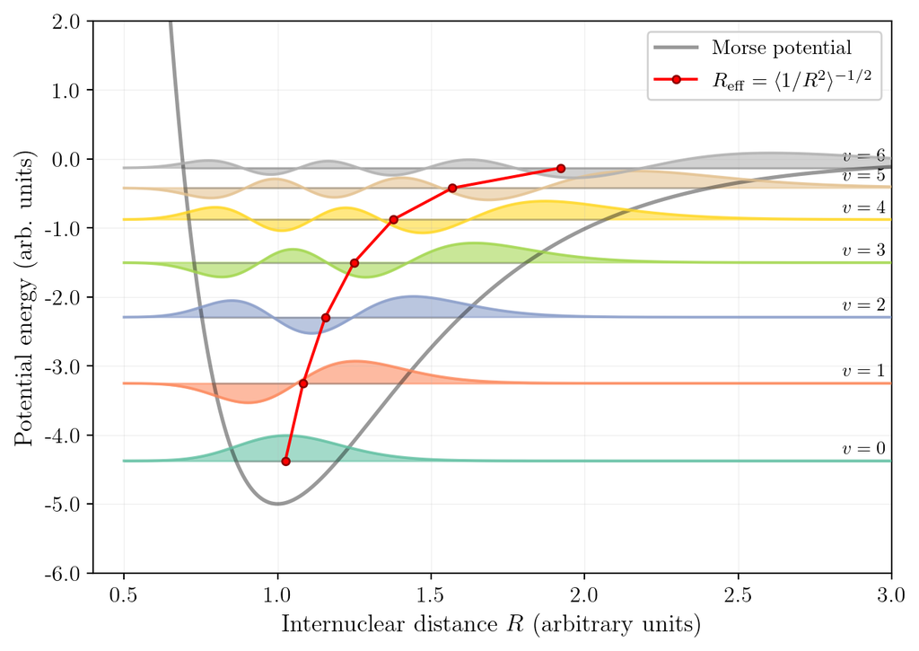

```python
import matplotlib.pyplot as plt
import numpy as np
from scipy.special import genlaguerre, gamma

# --- Set up plot styling ---
plt.rcParams['text.usetex'] = True
plt.rcParams['font.family'] = 'serif'
plt.rcParams['font.size'] = 12

def find_turning_points(R, V, E_v):
    """
    Find inner and outer classical turning points where V(R) = E_v
    Returns (R_min, R_max) or (None, None) if not found
    """
    diff = V - E_v
    # Find where sign changes (crossing points)
    sign_changes = np.where(np.diff(np.sign(diff)))[0]

    if len(sign_changes) >= 2:
        # Inner turning point (first crossing)
        R_min = R[sign_changes[0]]
        # Outer turning point (last crossing)
        R_max = R[sign_changes[-1]]
        return R_min, R_max
    else:
        R_min = R[sign_changes[0]]
        return R_min, 5

def morse_wavefunction(R, v, R_e, a, mu, E_B, hbar=1.0):
    """
    Calculate the Morse oscillator wavefunction for quantum number v

    Parameters:
    -----------
    R : array
        Internuclear distance
    v : int
        Vibrational quantum number
    R_e : float
        Equilibrium distance
    a : float
        Morse potential parameter
    mu : float
        Reduced mass
    E_B : float
        Binding energy (dissociation energy)
    hbar : float
        Reduced Planck constant

    Returns:
    --------
    psi : array
        Wavefunction values
    """
    # Morse potential parameters
    lambda_param = np.sqrt(2 * mu * E_B) / (a * hbar)

    # Dimensionless coordinate
    z = 2 * lambda_param * np.exp(-a * (R - R_e))

    # Maximum quantum number
    v_max = int(lambda_param - 0.5)

    if v > v_max:
        return np.zeros_like(R)

    # Normalization constant
    N_v = np.sqrt(
        (2 * lambda_param - 2 * v - 1) * a * gamma(v + 1) / gamma(2 * lambda_param - v)
    )

    # Generalized Laguerre polynomial
    L = genlaguerre(v, 2 * lambda_param - 2 * v - 1)

    # Wavefunction
    psi = N_v * z**(lambda_param - v - 0.5) * np.exp(-z / 2) * L(z)

    return psi

# Set up the figure
fig, ax = plt.subplots(1, 1, figsize=(7, 5))

# Parameters for the potentials
R_e = 1.0  # equilibrium distance (arbitrary units)
E_B = 5.0  # binding energy (eV)
k = 50.0   # force constant
mu = 30.0   # reduced mass (arbitrary units)
hbar = 1.0 # set to 1 for simplicity

# Calculate derived parameters
a = np.sqrt(k / (2 * E_B))
omega = np.sqrt(k / mu)
chi_e = (hbar * omega) / (4 * E_B)

# R values for plotting
R = np.linspace(0.5, 3.0, 1000)

# Morse potential
V_morse = E_B * (1 - np.exp(-a * (R - R_e)))**2

# Plot potential
ax.plot(R, V_morse, 'k-', linewidth=2, alpha=0.4, label='Morse potential', zorder=2)

# Plot vibrational levels and wavefunctions for Morse potential
n_levels_morse = int(1 / (2 * chi_e))  # maximum number of levels
v_values_morse = np.arange(0, min(n_levels_morse, 12))  # limit for clarity

# Color map for wavefunctions
colors = plt.cm.Set2(np.linspace(0, 1, len(v_values_morse)))

# Scale factor for wavefunction amplitude
scale = 0.2

for i, v in enumerate(v_values_morse):
    E_v = hbar * omega * (v + 0.5) - chi_e * hbar * omega * (v + 0.5)**2

    if E_v < E_B:  # only plot bound states
        # Calculate wavefunction
        psi = morse_wavefunction(R, v, R_e, a, mu, E_B, hbar)

        # Scale and shift wavefunction to energy level
        psi_scaled = scale * psi + E_v

        # Find turning points for horizontal line
        R_min, R_max = find_turning_points(R, V_morse, E_v)

        # Plot energy level line (only between turning points)
        if R_min is not None and R_max is not None:
            # Create mask for region between turning points
            mask = (R >= R_min) & (R <= R_max)

            # Plot horizontal line only in classical region
            ax.hlines(E_v, R_min, R_max, colors='gray', linewidth=1,
                     alpha=0.5, zorder=3)

        # Fill wavefunction
        ax.fill_between(R, E_v, psi_scaled, alpha=0.6, color=colors[i],
                       where=(psi_scaled >= E_v), interpolate=True)
        ax.fill_between(R, E_v, psi_scaled, alpha=0.6, color=colors[i],
                       where=(psi_scaled < E_v), interpolate=True)

        # Plot wavefunction line
        ax.plot(R, psi_scaled, color=colors[i], linewidth=1.5, alpha=0.8, zorder=4)

        # Add quantum number labels
        ax.text(2.98, E_v+0.05, f'$v={v}$', fontsize=10, va='bottom', ha='right')



# Use finer grid for integration
R_int = np.linspace(0.3, 5.0, 5000)

# Store values for plotting
R_eff_list = []
R_mean_list = []
E_v_list = []

for v in range(min(7, n_levels_morse)):
    E_v = hbar * omega * (v + 0.5) - chi_e * hbar * omega * (v + 0.5)**2

    if E_v < E_B:
        # Calculate wavefunction
        psi = morse_wavefunction(R_int, v, R_e, a, mu, E_B, hbar)

        # Calculate <1/R^2> = ∫ ψ*(R) (1/R²) ψ(R) dR
        integrand = psi**2 / R_int**2
        integrand2 = psi**2 * R_int

        # Numerical integration using trapezoidal rule
        expectation_value = np.trapezoid(integrand, R_int)
        R_mean = np.trapezoid(integrand2, R_int)
        R_eff = np.sqrt(1/expectation_value)

        # Store for plotting
        R_eff_list.append(R_eff)
        R_mean_list.append(R_mean)
        E_v_list.append(E_v)


# Plot R_eff and <R> on the existing figure
R_eff_array = np.array(R_eff_list)
R_mean_array = np.array(R_mean_list)
E_v_array = np.array(E_v_list)

# Plot points and connecting lines
ax.plot(R_eff_array, E_v_array, 'o-', color='red', linewidth=1.5,
        markersize=4, label=r'$R_{\mathrm{eff}} = \langle 1/R^2 \rangle^{-1/2}$',
        zorder=10, markeredgecolor='darkred', markeredgewidth=1)



# Labels and formatting
ax.set_xlabel('Internuclear distance $R$ (arbitrary units)', fontsize=13)
ax.set_ylabel('Potential energy (arb. units)', fontsize=13)
ax.legend(loc='upper right', fontsize=11, framealpha=0.9)
ax.set_xlim(0.4, 3.0)
ax.set_ylim(-0.5, 6.5)
ax.grid(True, alpha=0.2, linestyle='-', linewidth=0.5)

# Get current y-axis tick locations
yticks = ax.get_yticks()
ax.set_yticks(yticks)

# Set new labels (shifted)
ax.set_yticklabels([f'{y - 5:.1f}' for y in yticks])


plt.tight_layout()
plt.show()
```

## 4.2 Effect of Rotation on the Effective Potential

The centrifugal force arising from rotation modifies the effective potential experienced during vibration. The **rotational barrier** adds a term to the potential:

$$V_{\text{eff}}(R) = E_n^{el}(R) + \frac{J(J+1)\hbar^2}{2\mu R^2}$$

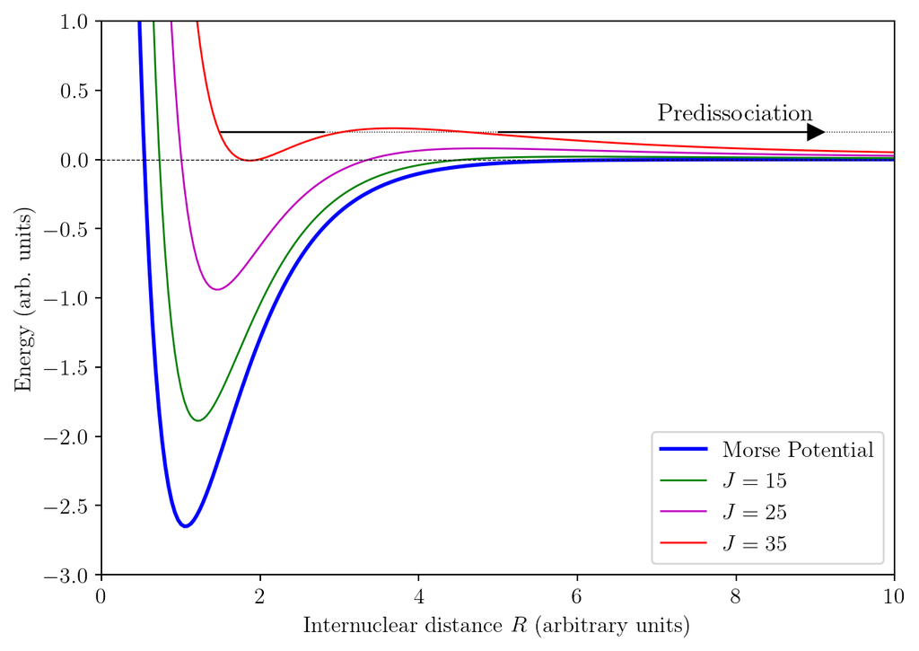

```python
import numpy as np
import matplotlib.pyplot as plt

# --- Potential functions ---
def morse_potential(R, Eb, Re, a):
    """
    Calculates the potential energy using the Morse potential function.

    Args:
        R (float or np.ndarray): Internuclear distance.
        Eb (float): Dissociation energy (depth of the well).
        Re (float): Equilibrium bond length.
        a (float): Constant that controls the width of the potential curve.

    Returns:
        float or np.ndarray: Potential energy E at distance R.
    """
    return Eb * (1 - np.exp(-a * (R - Re)))**2 - Eb

def rot_barrier(R, J, M):
    return 27.2*J*(J+1)/((1836*M)*(R*1.9)**2) # in eV



# --- Set up plot styling ---
plt.rcParams['text.usetex'] = True
plt.rcParams['font.family'] = 'serif'
plt.rcParams['font.size'] = 12


# --- Define parameters for the potentials ---
# Parameters for NaCl using Morse and Born-Mayer potentials
# Note: These values are simplified and may need unit conversions for physical accuracy.
# Morse potential parameters for NaCl (approximate)
morse_Eb = 2.651  # eV, bond dissociation energy
morse_Re = 1.058  # Å, equilibrium bond length
morse_a = 1.338   # Å^-1, width parameter

rot_J = 35
rot_m = 1

# --- Generate data points ---
# Create an array of internuclear distances (R)
R = np.linspace(0.001, 20, 500)
#R2 = np.linspace(0.5, 100, 500)

# Calculate the potential energy for each model
E_morse = morse_potential(R, morse_Eb, morse_Re, morse_a)
E_rot = rot_barrier(R,rot_J,rot_m)

# --- Plotting ---
fig, ax = plt.subplots(figsize=(7,5))

ax.plot([1.5,10],[0.2,0.2], color='k', lw=0.5, linestyle=':')
ax.plot([1.5,2.8],[0.2,0.2], color='k', lw=1, linestyle='-')
ax.plot([5,9],[0.2,0.2], color='k', lw=1, linestyle='-')
ax.plot(9, 0.2, ">k", clip_on=False, markersize=8)
ax.text(8, 0.2+0.05, r'Predissociation', fontsize=13, va='bottom', ha='center')


# Plot the Morse potential
ax.plot(R, E_morse, label=r'Morse Potential', color='blue', lw=2)
ax.plot(R, E_morse+rot_barrier(R,15,rot_m) , label=r'$J=15$', color='g', lw=1)
ax.plot(R, E_morse+rot_barrier(R,25,rot_m) , label=r'$J=25$', color='m', lw=1)
ax.plot(R, E_morse+E_rot, label=r'$J=35$', color='r', lw=1)



# Set plot labels and title
ax.set_xlabel(r'Internuclear distance $R$ (arbitrary units)')
ax.set_ylabel(r'Energy (arb. units)')
#ax.set_title(r'Comparison of Morse and Born-Mayer Potentials (NaCl approx.)')

# Add a legend to distinguish the curves
ax.legend(loc='lower right')

# Add a horizontal line at E=0 for reference
ax.axhline(0, color='k', lw=0.5, linestyle='--')

# Set plot limits
ax.set_xlim([0, 10])
ax.set_ylim([-3, 1])

plt.tight_layout()
plt.show()
```

**Summary:** Vibrational levels generally depend on the rotational quantum number $J$. The coupling between rotation and vibration leads to:  
- A $v$-dependent rotational constant: $B_v = B_e - \alpha_e(v + \frac{1}{2})$  
- A $J$-dependent effective potential that can limit the number of bound states at high angular momentum

## 4.3 Spectroscopic Consequences

The coupling between rotation and vibration has important consequences for molecular spectroscopy. If the Morse potential description is valid, the rovibrational energies can be expressed using five molecular constants:

$$E(v,J) = T_e + \hbar\omega_e\left(v + \frac{1}{2}\right) - \hbar\omega_e\chi_e\left(v + \frac{1}{2}\right)^2 + B_v J(J+1) - D_J[J(J+1)]^2$$

where:  
- $T_e$ is the term value (electronic energy origin)  
- $\omega_e$ is the harmonic vibrational frequency  
- $\omega_e\chi_e$ characterizes the anharmonicity  
- $B_v = B_e - \alpha_e(v + \frac{1}{2})$ is the vibration-dependent rotational constant  
- $D_J$ accounts for centrifugal distortion

These five constants ($T_e$, $\omega_e$, $\omega_e\chi_e$, $B_e$, $\alpha_e$, plus $D_J$ if needed) can be determined from high-resolution rovibrational spectra and provide a complete characterization of the molecular potential energy curve near its minimum.

The analysis of rovibrational spectra thus provides detailed information about:  
- The shape of the potential energy curve  
- The bond strength (dissociation energy)  
- The equilibrium bond length  
- The force constant and anharmonicity  
- Coupling effects between different degrees of freedom

# Key Takeaways

- The **Born–Oppenheimer approximation** exploits the large mass difference between nuclei and electrons to separate their motions. Electrons adjust almost instantaneously to the nuclear configuration, defining **potential energy surfaces** on which the nuclei move.
- The **electronic Schrödinger equation** yields potential energy curves $E^{el}(R)$ that serve as **effective potentials** for the nuclear motion. The resulting **nuclear Schrödinger equation** describes vibrations and rotations on these surfaces.
- For a diatomic molecule, the nuclear motion reduces to the **radial coordinate** $R$ and the **angular momentum** associated with rotation. The nuclear Hamiltonian takes the form

  $$\hat{H}_{\text{nuc}} = -\frac{\hbar^2}{2\mu}\frac{d^2}{dR^2}
  + \frac{\hbar^2 J(J+1)}{2\mu R^2} + E^{el}(R),$$
  where $\mu$ is the reduced mass and $J$ the rotational quantum number.
- The **rigid-rotor model** predicts discrete rotational energies $E_J = B J(J+1)$ with $B = \hbar^2/(2I)$. Transitions follow the selection rule $\Delta J = \pm 1$, giving rise to evenly spaced rotational spectra.
- The **harmonic-oscillator model** describes small-amplitude vibrations with quantized energies  
  $E_v = \hbar \omega (v + \tfrac{1}{2})$.  
  Real molecules exhibit **anharmonic corrections** that lead to unequal level spacings and finite dissociation energies.
- **Rotational–vibrational coupling** slightly modifies the spacing of rotational lines with increasing vibrational excitation, reflecting bond stretching at higher vibrational states.
- **Nuclear spin statistics** determine which rotational levels are allowed for homonuclear molecules, leading to the familiar **ortho–para forms** (e.g., ortho- and para-hydrogen).

### Typical Energy Scales

| Type of motion | Typical energy spacing | Wavelength region | Example |
| --- | --- | --- | --- |
| **Electronic** | 1–10 eV | 100–1000 nm (UV/visible) | Electronic transitions in H₂ |
| **Vibrational** | 0.1 eV (≈1000 cm⁻¹) | 2–20 µm (infrared) | Stretching mode of CO |
| **Rotational** | 10⁻³ eV (≈1–10 cm⁻¹) | 0.3–3 mm (microwave) | Pure rotational lines of HCl |

Together, these results link the microscopic quantum-mechanical description of the molecule to its **spectroscopic signatures**, completing the physical picture of the diatomic molecule as a quantized, rotating, and vibrating system.